# ST 558 Homework 5

Eric Warren

2023-09-28

# Task 1 - Reading in the Data

We are going to read in and modify our code in two ways.

- The first way we are going to do it is by modifying the code provided with the download to read in the data from a local file source (our downloaded .csv files) and combine the two data frames. We will use local paths as they do in their code.

```r
library(tidyverse)
# Read in both tables
math_scores <- read.table("student-mat.csv", sep=";", header=TRUE)
port_scores <- read.table("student-por.csv", sep=";", header=TRUE)

# Combine the data together
combined_scores <- merge(math_scores,
                         port_scores,
                         by = c("school", "sex", "age", "address", "famsize", "Pstatus", "Medu", "Fedu", "Mjob", "Fjob", "reason", "nursery", "internet"))

# Change the data to a tibble and print the combined data
combined_scores <- as_tibble(combined_scores)
combined_scores
```

```
## # A tibble: 382 × 53
##    school sex     age address famsize Pstatus  Medu  Fedu Mjob     Fjob   reason
##    <chr>  <chr> <int> <chr>   <chr>   <chr>   <int> <int> <chr>    <chr>  <chr>
##  1 GP     F        15 R       GT3     T           1     1 at_home  other  home
##  2 GP     F        15 R       GT3     T           1     1 other    other  reput…
##  3 GP     F        15 R       GT3     T           2     2 at_home  other  reput…
##  4 GP     F        15 R       GT3     T           2     4 services health course
##  5 GP     F        15 R       GT3     T           3     3 services servi… reput…
##  6 GP     F        15 R       GT3     T           3     4 services health course
##  7 GP     F        15 R       GT3     T           3     4 services teach… course
##  8 GP     F        15 R       LE3     T           2     2 health   servi… reput…
##  9 GP     F        15 R       LE3     T           3     1 other    other  reput…
## 10 GP     F        15 U       GT3     A           3     3 other    health reput…
## # ℹ 372 more rows
## # ℹ 42 more variables: nursery <chr>, internet <chr>, guardian.x <chr>,
## #   traveltime.x <int>, studytime.x <int>, failures.x <int>, schoolsup.x <chr>,
## #   famsup.x <chr>, paid.x <chr>, activities.x <chr>, higher.x <chr>,
## #   romantic.x <chr>, famrel.x <int>, freetime.x <int>, goout.x <int>,
## #   Dalc.x <int>, Walc.x <int>, health.x <int>, absences.x <int>, G1.x <int>,
## #   G2.x <int>, G3.x <int>, guardian.y <chr>, traveltime.y <int>, …
```

- Now we are going to read in and combine the data using functions from the tidyverse. Use an `dplyr::inner_join()` on the variables they used in their code. Do you notice any issues? Make a note of the issue.

```r
# Read in the data
math_scores2 <- read_delim("student-mat.csv", delim = ";")
port_scores2 <- read_delim("student-por.csv", delim = ";")

# Combine the data using dplyr::inner_join()
combined_scores2 <- dplyr::inner_join(math_scores, port_scores, by = c("school", "sex", "age", "address", "famsize", "Pstatus", "Medu", "Fedu", "Mjob", "Fjob", "reason", "nursery", "internet"))
# Show the multiple columns
combined_scores2
```

```
## # A tibble: 382 × 53
##    school sex     age address famsize Pstatus  Medu  Fedu Mjob     Fjob   reason
##    <chr>  <chr> <int> <chr>   <chr>   <chr>   <int> <int> <chr>    <chr>  <chr>
##  1 GP     F        18 U       GT3     A           4     4 at_home  teach… course
##  2 GP     F        17 U       GT3     T           1     1 at_home  other  course
##  3 GP     F        15 U       LE3     T           1     1 at_home  other  other
##  4 GP     F        15 U       GT3     T           4     2 health   servi… home
##  5 GP     F        16 U       GT3     T           3     3 other    other  home
##  6 GP     M        16 U       LE3     T           4     3 services other  reput…
##  7 GP     M        16 U       LE3     T           2     2 other    other  home
##  8 GP     F        17 U       GT3     A           4     4 other    teach… home
##  9 GP     M        15 U       LE3     A           3     2 services other  home
## 10 GP     M        15 U       GT3     T           3     4 other    other  home
## # ℹ 372 more rows
## # ℹ 42 more variables: guardian.x <chr>, traveltime.x <int>, studytime.x <int>,
## #   failures.x <int>, schoolsup.x <chr>, famsup.x <chr>, paid.x <chr>,
## #   activities.x <chr>, nursery <chr>, higher.x <chr>, internet <chr>,
## #   romantic.x <chr>, famrel.x <int>, freetime.x <int>, goout.x <int>,
## #   Dalc.x <int>, Walc.x <int>, health.x <int>, absences.x <int>, G1.x <int>,
## #   G2.x <int>, G3.x <int>, guardian.y <chr>, traveltime.y <int>, …
```

Here we can see that there is a many to many relationship between both datasets that are in question. This creates another set of extra columns that are created with duplicate data.

- We are going to fix this by having all the by variables being all of them except `absences`, `G1`, `G2`, and `G3`.

```r
# Select the variables we need to join by
combined_variables <- math_scores2 %>%
  select(-c(G1, G2, G3, absences)) %>%
  colnames()

# Make the new combined data set with these variables
combined_scores3 <- dplyr::inner_join(math_scores2, port_scores2, by = combined_variables)

# Rename .x and .y columns
colnames(combined_scores3) <- gsub('.x', '.math', colnames(combined_scores3))
colnames(combined_scores3)[2] <- "sex"
colnames(combined_scores3) <- gsub('.y', '.port', colnames(combined_scores3))

# Show this new data set
combined_scores3
```

```
## # A tibble: 162 × 37
##    school sex     age address famsize Pstatus  Medu  Fedu Mjob     Fjob   reason
##    <chr>  <chr> <dbl> <chr>   <chr>   <chr>   <dbl> <dbl> <chr>    <chr>  <chr>
##  1 GP     F        18 U       GT3     A           4     4 at_home  teach… course
##  2 GP     F        17 U       GT3     T           1     1 at_home  other  course
##  3 GP     M        16 U       LE3     T           2     2 other    other  home
##  4 GP     F        17 U       GT3     A           4     4 other    teach… home
##  5 GP     F        15 U       GT3     T           2     1 services other  reput…
##  6 GP     M        15 U       GT3     A           2     2 other    other  home
##  7 GP     F        16 U       GT3     T           4     4 health   other  home
##  8 GP     F        16 U       GT3     T           3     3 other    other  reput…
##  9 GP     M        15 U       GT3     T           4     3 teacher  other  reput…
## 10 GP     M        15 U       GT3     T           4     4 health   health other
## # ℹ 152 more rows
## # ℹ 26 more variables: guardian <chr>, traveltime <dbl>, stu.porttime <dbl>,
## #   failures <dbl>, schoolsup <chr>, famsup <chr>, paid <chr>,
## #   activities <chr>, nurse.port <chr>, higher <chr>, internet <chr>,
## #   romantic <chr>, famrel <dbl>, freetime <dbl>, goout <dbl>, Dalc <dbl>,
## #   Walc <dbl>, health <dbl>, absences.math <dbl>, G1.math <dbl>,
## #   G2.math <dbl>, G3.math <dbl>, absences.port <dbl>, G1.port <dbl>, …
```

- We are now going to pick 4 categorical variables we are interested in. Those will be `sex`, `famsize`, `higher`, `internet` and we are going to turn them into factors to make it easier to analyze. We are using the `mutate()` function to do this.

```r
# Change the math scores
math_scores2 <- math_scores2 %>%
  mutate(sex = factor(sex, labels = c("Female", "Male")),
         famsize = factor(famsize),
         higher = factor(higher),
         internet = factor(internet))

# Change the Portuguese scores
port_scores2 <- port_scores2 %>%
  mutate(sex = factor(sex, labels = c("Female", "Male")),
         famsize = factor(famsize),
         higher = factor(higher),
         internet = factor(internet))

# Change the combined data set
combined_scores3 <- combined_scores3 %>%
  mutate(sex = factor(sex, labels = c("Female", "Male")),
         famsize = factor(famsize),
         higher = factor(higher),
         internet = factor(internet))
```

# Task 2 - Summarize the Data (Very Basic EDA)

We’ve talked about summarizing data. That’s the essential idea of an exploratory data analysis (EDA). We try to understand numerically and visually the data we are working with. For now we’ll do a basic EDA by doing the following on the combined data (`combined_scores3`):

## Categorical Variables

Here we are going to create a one-way contingency table, a two-way contingency table, and a three-way contingency table for some of the factor variables we created previously. Use `table()` to accomplish this.

- Here we are going to create a one-way table based on `sex`.

```r
tbl1 <- table(combined_scores3$sex)
tbl1
```

```
##
## Female   Male
##     80     82
```

As we can see here, the breakdown of males and females as students is about even with 50.62% of the data being males and the rest (or 49.38%) being females. So as we can see it is fairly even.

- Here we are going to create a two-way tables based on `sex` and `internet`.

```r
tbl2 <- table(combined_scores3$sex, combined_scores3$internet)
tbl2
```

```
##
##          no yes
##   Female 19  61
##   Male   15  67
```

As we can see here, the breakdown of males and females with internet is about even, but people tend to have more internet access than those who don’t. We can see that 76.25% of females have internet and 81.71% of males have internet. So this shows that most students do have this access with both sexes having this access.

- Here we are going to create a three-way tables based on `sex`, `internet`, and `higher`.

```r
tbl3 <- table(combined_scores3$sex, combined_scores3$internet, combined_scores3$higher)
tbl3
```

```
## , ,  = no
##
##
##          no yes
##   Female  0   2
##   Male    0   4
##
## , ,  = yes
##
##
##          no yes
##   Female 19  59
##   Male   15  63
```

When looking at this table, it is interesting to see that students mostly want to take higher level classes. Very few students are not interested in doing so. We can also see that all students who are not interested in higher level courses all have internet. This is an interesting trend to look at but the small sample size might cause this and not actually be normal.

Here we are going to create a conditional two-way table using `table()`. That is, condition on one variable’s setting and create a two-way table. Do this using two different methods:

- Once, by subsetting the data (say with `filter()`) and then creating the two-way table

```r
#filter the data by higher = yes
filter_combined_scores <- combined_scores3 %>%
  filter(higher == "yes")

#Make table of filtered data
table(filter_combined_scores$sex, filter_combined_scores$internet)
```

```
##
##          no yes
##   Female 19  59
##   Male   15  63
```

As we can see this two way table shows the breakdown of the sex of a student and whether they have internet or not. This breakdown is conditioned on if the student wants to take higher education classes. This is very similar to our three-way contingency table where it was the second part of the table of `, , = yes`.

- Once, by creating a three-way table and subsetting it. Note, we have already created a three-way table called `tbl3` but we will recall it in so users can remember this. Then we will subset it by saying that `higher = yes` from before.

```r
# Recall the three way table
tbl3 <- table(combined_scores3$sex, combined_scores3$internet, combined_scores3$higher)

# Produce subset table with higher = yes
tbl3[ , , "yes"]
```

```
##
##          no yes
##   Female 19  59
##   Male   15  63
```

As we can see this two way table shows the breakdown of the sex of a student and whether they have internet or not. This breakdown is conditioned on if the student wants to take higher education classes. This is the exact same as our two-way table above where we used `filter` to subset the data.

Now we are going to create a two-way contingency table using `group_by()` and `summarize()` from dplyr. Then use `pivot_wider()` to make the result look more like the output from `table()`.

```r
combined_scores3 %>%
  group_by(sex, internet) %>%
  summarize(count = n()) %>%
  pivot_wider(names_from = internet, values_from = count)
```

```
## # A tibble: 2 × 3
##   sex       no   yes
##   <fct>  <int> <int>
## 1 Female    19    61
## 2 Male      15    67
```

As we can see this looks very similar to our two way tables created from before. Actually if we look at our two way table created before without values being filtered (`tbl2`).

```r
tbl2
```

```
##
##          no yes
##   Female 19  61
##   Male   15  67
```

Again we can see doing this `group_by()`, `summarize()`, and `pivot_wider()` method basically shows the same thing (other than how the object is being stored) as if we just use the `tbl()` function.

Now we are going to create a stacked bar graph and a side-by-side bar graph. Give relevant x and y labels, and a title for the plots.

- First we will show the stacked bar graph. We will have the x-axis be the `sex` of the student and the grouping variable or what we will call the fill section being `internet` access.

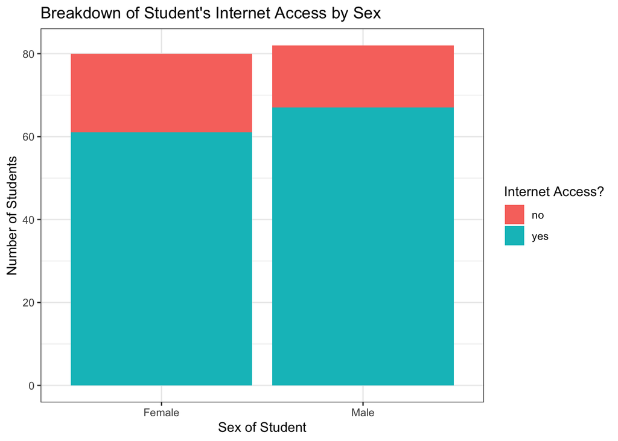

```r
ggplot(combined_scores3, aes(x = sex)) +
  geom_bar(position = "stack", aes(fill = internet)) +
  labs(x = "Sex of Student",
       y = "Number of Students",
       fill = "Internet Access?",
       title = "Breakdown of Student's Internet Access by Sex") +
  theme_bw()
```

Our big takeaway from this graph is that there are a larger proportion of female students who do not have internet access.

- Now we are going to make a side by side bar plot. This will again show (like the stacked bar plot) the x-axis being the `sex` of the student and the grouping variable or what we will call the fill section being `internet` access.

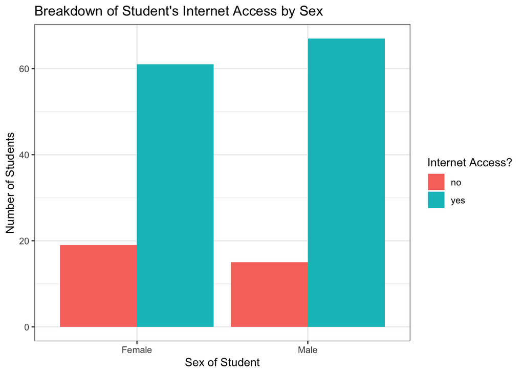

```r
ggplot(combined_scores3, aes(x = sex)) +
  geom_bar(position = "dodge", aes(fill = internet)) +
  labs(x = "Sex of Student",
       y = "Number of Students",
       fill = "Internet Access?",
       title = "Breakdown of Student's Internet Access by Sex") +
  theme_bw()
```

This gives a nicer representation showing that both sexes of students have internet access with slightly more males who have it and slightly more females who do not. The stacked barplot in my opinion shows the proportions better while the side-by-side barplot shows the number of each category better.

## Numeric Variables

The numeric variables are `age`, `absences`, and the three test grades variables (`G1`, `G2`, and `G3`) from each data set (math and Portuguesse).

Find measures of center and spread for three of these variables (including at least one G3 variable). For the measure of center we will find the **mean** and for the spread we will find the **standard deviation**. The variables we will look at is `absences`, `G1`, and `G3` all from the math scores (since I like math better and thought it would be more interesting to look at this).

```r
math_scores2 %>%
  select(absences, G1, G3) %>%
  summarise_all(list(mean = mean, stddev = sd)) %>%
  pivot_longer(names_to = "measure", values_to = "output", cols = absences_mean:G3_stddev) %>%
  separate(measure, c("variable", "statistic"), "_") %>%
  pivot_wider(names_from = "statistic", values_from = "output")
```

```
## # A tibble: 3 × 3
##   variable  mean stddev
##   <chr>    <dbl>  <dbl>
## 1 absences  5.71   8.00
## 2 G1       10.9    3.32
## 3 G3       10.4    4.58
```

Here we can see that the spread in `absences` is very large. This makes us think some outliers could be present with a standard deviation so much higher than the mean. The mean scores between `G1` and `G3` are fairly close but the spread in scores is much larger. Scores are given from 0-20 so we could also guess more students might have scored higher on `G3` than `G1` (assuming normality using the Central Limit Theorem) but also the reverse or more students scoring worse (which could bring down the average and increase the spread in our data).

```r
math_scores2 %>%
  filter(absences <= 10) %>%
  select(absences, G1, G3) %>%
  summarise_all(list(mean = mean, stddev = sd)) %>%
  pivot_longer(names_to = "measure", values_to = "output", cols = absences_mean:G3_stddev) %>%
  separate(measure, c("variable", "statistic"), "_") %>%
  pivot_wider(names_from = "statistic", values_from = "output")
```

```
## # A tibble: 3 × 3
##   variable  mean stddev
##   <chr>    <dbl>  <dbl>
## 1 absences  3.05   3.06
## 2 G1       11.0    3.34
## 3 G3       10.5    4.82
```

As we can see now, removing the large absence amounts show that students do not miss many days. The test scores are about the same as before (going up roughly a tenth of a point on average), but the spread (standard deviation) goes up because we have less students in our data set (which shows this wide range of scores still exists and is not because of students missing school).

Find measures of center and spread across a single grouping variable for three of these variables (including a G3 variable as one of them). For the measure of center we will find the **mean** and for the spread we will find the **standard deviation**. The variables we will look at is `absences`, `G1`, and `G3` all from the math scores (as we did before to keep it consistent). Our grouping variable will now be the `sex` of the student.

```r
math_scores2 %>%
  select(sex, absences, G1, G3) %>%
  group_by(sex) %>%
  summarise_all(list(mean = mean, stddev = sd)) %>%
  pivot_longer(names_to = "measure", values_to = "output", cols = absences_mean:G3_stddev) %>%
  separate(measure, c("variable", "statistic"), "_") %>%
  pivot_wider(names_from = "statistic", values_from = "output")
```

```
## # A tibble: 6 × 4
##   sex    variable  mean stddev
##   <fct>  <chr>    <dbl>  <dbl>
## 1 Female absences  6.22   9.45
## 2 Female G1       10.6    3.23
## 3 Female G3        9.97   4.62
## 4 Male   absences  5.14   5.98
## 5 Male   G1       11.2    3.39
## 6 Male   G3       10.9    4.50
```

As we can see, females on average have more `absences` but their standard deviation is much larger meaning they probably had more outliers to drive up this total. The female grades on both exams (`G1` and `G3`) were also lower than male counterparts with the spreads not being too far off. Our initial hunch before doing any statistical testing to back up the claim is that males might score better on math tests than females.

Find measures of center and spread across two grouping variables for three of these variables (including a G3 variable as one of them). For the measure of center we will find the **mean** and for the spread we will find the **standard deviation**. The variables we will look at is `absences`, `G1`, and `G3` all from the math scores (as we did before to keep it consistent). Our grouping variables will now be the `sex` of the student (from before) and if the student wants to take higher education classes (`higher`).

```r
math_scores2 %>%
  select(sex, higher, absences, G1, G3) %>%
  group_by(sex, higher) %>%
  summarise_all(list(mean = mean, stddev = sd)) %>%
  pivot_longer(names_to = "measure", values_to = "output", cols = absences_mean:G3_stddev) %>%
  separate(measure, c("variable", "statistic"), "_") %>%
  pivot_wider(names_from = "statistic", values_from = "output")
```

```
## # A tibble: 12 × 5
##    sex    higher variable  mean stddev
##    <fct>  <fct>  <chr>    <dbl>  <dbl>
##  1 Female no     absences 24.2   35.0
##  2 Female no     G1        9.25   3.59
##  3 Female no     G3        7.75   5.5
##  4 Female yes    absences  5.86   8.14
##  5 Female yes    G1       10.6    3.23
##  6 Female yes    G3       10.0    4.61
##  7 Male   no     absences  3.5    5.28
##  8 Male   no     G1        8.12   2.85
##  9 Male   no     G3        6.56   4.82
## 10 Male   yes    absences  5.30   6.03
## 11 Male   yes    G1       11.5    3.30
## 12 Male   yes    G3       11.3    4.26
```

We can see that males tend to score better than females if a student wants to take higher education classes, but females tend to do better if a student does not want to take higher education classes. It is not surprising for females that students who do *not* want to take higher education classes have more absences (except the extremely large spread is probably do a large outlier and small number of people in this category). It is surprising for males though that students who might not like school as much (those not planning on taking higher education classes) have on average less absences than male students who do.

Create a correlation matrix between all of the numeric variables which said before were `absences`, `age`, `G1`, `G2`, and `G3`.

- First we will do it for the `math` variables.

```r
# Get correlations for all numeric data
numeric_vars <- c("absences", "age", "G1", "G2", "G3")
correlation_math <- cor(select(math_scores2, all_of(numeric_vars)), method = "spearman")
correlation_math # Correlation matrix
```

```
##              absences         age           G1          G2          G3
## absences  1.000000000  0.14927633  0.004479359 -0.03359985  0.01773067
## age       0.149276326  1.00000000 -0.057630019 -0.16762153 -0.17343755
## G1        0.004479359 -0.05763002  1.000000000  0.89479162  0.87800130
## G2       -0.033599848 -0.16762153  0.894791617  1.00000000  0.95712533
## G3        0.017730669 -0.17343755  0.878001297  0.95712533  1.00000000
```

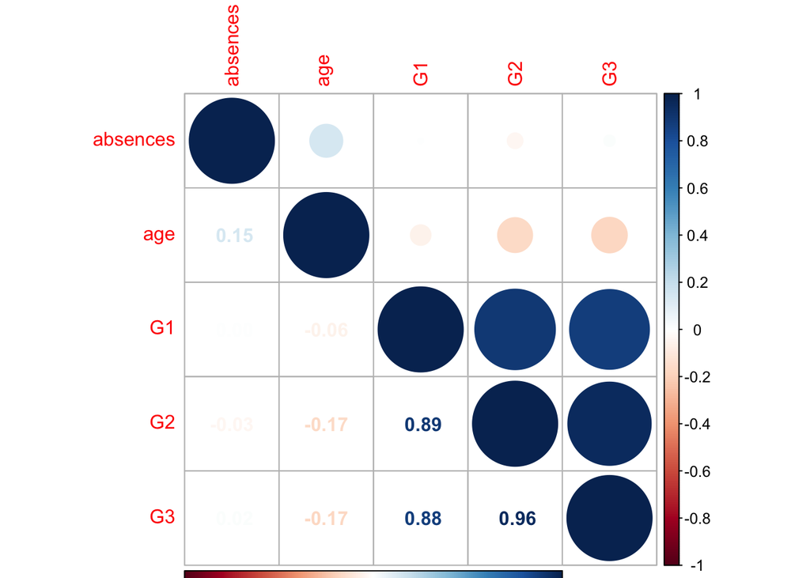

```r
# Make correlation matrix plot
library(corrplot)
corrplot(correlation_math)
corrplot(correlation_math, type = "lower", method = "number", add = TRUE, diag = FALSE, tl.pos = "n")
```

We can see from this that there is a lot of correlation between the `G1`, `G2`, and `G3` scores but not the `age` or `absences`.

- Next we will do it for the `port` variables.

```r
# Get correlations for all numeric data
numeric_vars <- c("absences", "age", "G1", "G2", "G3")
correlation_port <- cor(select(port_scores2, all_of(numeric_vars)), method = "spearman")
correlation_port # Correlation matrix
```

```
##            absences         age         G1         G2          G3
## absences  1.0000000  0.12426050 -0.1704299 -0.1638854 -0.15851003
## age       0.1242605  1.00000000 -0.1673732 -0.1055950 -0.06627695
## G1       -0.1704299 -0.16737325  1.0000000  0.8930649  0.88328764
## G2       -0.1638854 -0.10559495  0.8930649  1.0000000  0.94445119
## G3       -0.1585100 -0.06627695  0.8832876  0.9444512  1.00000000
```

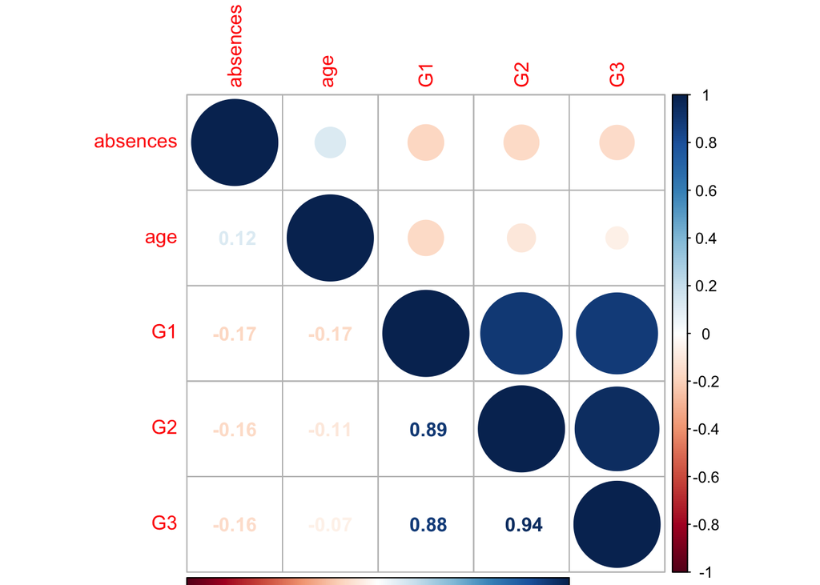

```r
# Make correlation matrix plot
library(corrplot)
corrplot(correlation_port)
corrplot(correlation_port, type = "lower", method = "number", add = TRUE, diag = FALSE, tl.pos = "n")
```

Same as math, we can see from this that there is a lot of correlation between the `G1`, `G2`, and `G3` scores but not the `age` or `absences`.

- Lastly, we will do it for the `combined` variables.

```r
# Get correlations for all numeric data
correlation_both <- cor(select(combined_scores3, c("age", contains("G1"), contains("G2"), contains("G3"), contains("absences"))), method = "spearman")
correlation_both # Correlation matrix
```

```
##                       age     G1.math     G1.port     G2.math     G2.port
## age            1.00000000 -0.19077100 -0.09270645 -0.23696982 -0.08742949
## G1.math       -0.19077100  1.00000000  0.58173683  0.90761814  0.62564601
## G1.port       -0.09270645  0.58173683  1.00000000  0.56536971  0.88841005
## G2.math       -0.23696982  0.90761814  0.56536971  1.00000000  0.63748628
## G2.port       -0.08742949  0.62564601  0.88841005  0.63748628  1.00000000
## G3.math       -0.23029835  0.89049560  0.54664475  0.96160746  0.62816153
## G3.port       -0.03799473  0.63086041  0.85419972  0.60045681  0.93563648
## absences.math  0.15734665 -0.01400671 -0.02984660 -0.05474178 -0.05858625
## absences.port  0.07337110 -0.04061073 -0.06451762 -0.09620652 -0.06745926
##                   G3.math     G3.port absences.math absences.port
## age           -0.23029835 -0.03799473    0.15734665    0.07337110
## G1.math        0.89049560  0.63086041   -0.01400671   -0.04061073
## G1.port        0.54664475  0.85419972   -0.02984660   -0.06451762
## G2.math        0.96160746  0.60045681   -0.05474178   -0.09620652
## G2.port        0.62816153  0.93563648   -0.05858625   -0.06745926
## G3.math        1.00000000  0.61546575   -0.03076142   -0.13074533
## G3.port        0.61546575  1.00000000   -0.04455625   -0.03887687
## absences.math -0.03076142 -0.04455625    1.00000000    0.39819927
## absences.port -0.13074533 -0.03887687    0.39819927    1.00000000
```

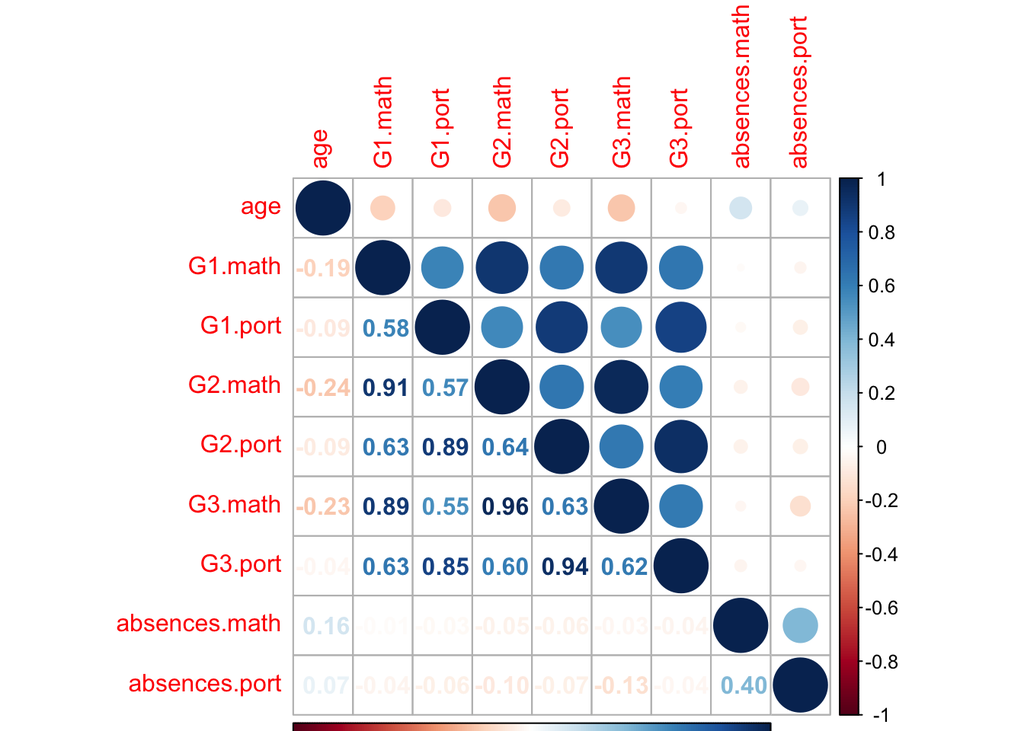

```r
# Make correlation matrix plot
library(corrplot)
corrplot(correlation_both)
corrplot(correlation_both, type = "lower", method = "number", add = TRUE, diag = FALSE, tl.pos = "n")
```

We can actually see that there is a fair amount of correlation between the `G1`, `G2`, and `G3` scores for math and Portuguese. This might show that students who do well in one subject will do well in the other and vice versa. We should explore this trend more later on if we want to conclude this.

- Let us look at `G1` scores with the grouping variable of `sex`. The write-up with some takeaways will be after the three plots.

First we are going to make the histogram of `G1` scores with the grouping variable of `sex`.

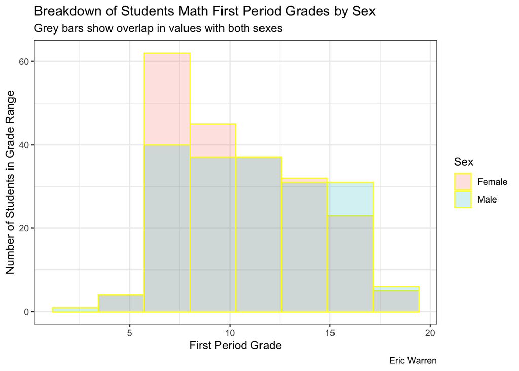

```r
ggplot(math_scores2) +
  geom_histogram(aes(x = G1, fill = sex),
                 col = "yellow",
                 bins = 8,
                 alpha = 0.2,
                 position = "identity") +
  labs(x = "First Period Grade",
       y = "Number of Students in Grade Range",
       title = "Breakdown of Students Math First Period Grades by Sex",
       fill = "Sex",
       caption = "Eric Warren",
       subtitle = "Grey bars show overlap in values with both sexes") +
  theme_bw()
```

Now we are going to make the density plot of `G1` scores with the grouping variable of `sex`.

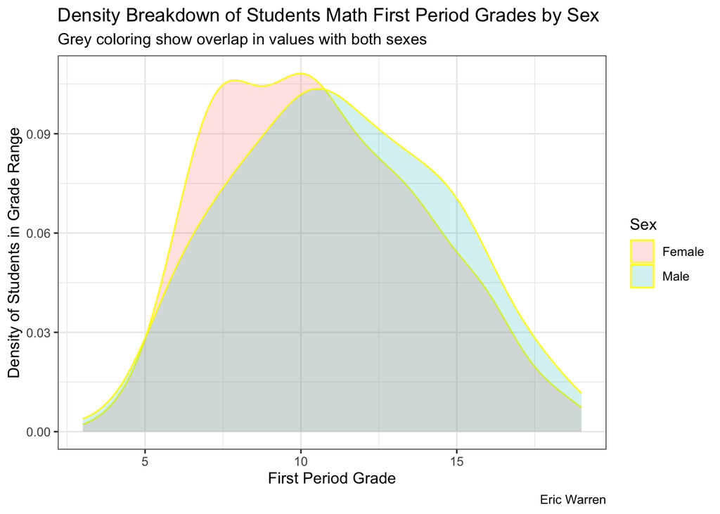

```r
ggplot(math_scores2) +
  geom_density(aes(x = G1, fill = sex),
                 col = "yellow",
                 alpha = 0.2,
                 position = "identity") +
  labs(x = "First Period Grade",
       y = "Density of Students in Grade Range",
       title = "Density Breakdown of Students Math First Period Grades by Sex",
       fill = "Sex",
       caption = "Eric Warren",
       subtitle = "Grey coloring show overlap in values with both sexes") +
  theme_bw()
```

Now we are going to make the boxplot of `G1` scores with the grouping variable of `sex`.

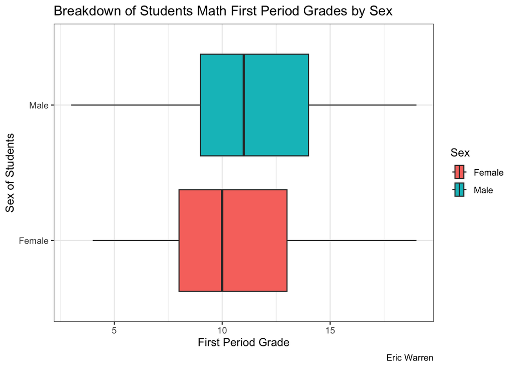

```r
ggplot(math_scores2) +
  geom_boxplot(aes(x = G1, y = sex, fill = sex)) +
  labs(x = "First Period Grade",
       y = "Sex of Students",
       title = "Breakdown of Students Math First Period Grades by Sex",
       fill = "Sex",
       caption = "Eric Warren") +
  theme_bw()
```

It is interesting to see how males and female scores are relatively the same for the first period grade in math, but it seems like there are more females who get lower scores and the males tend to be better than the females getting higher final scores (since there are more number of males in the upper level scores). There seems to be an outlier on the lower end with a male not performing too well and it would be interesting to see why this student performed so much lower. Since the number of males and females are roughly the same, we can ponder if males perform better than females in math. In the boxplot, especially, we can see median, lower quartile, and upper quartile first period grades for males are higher than females.

Now we are going to make the histogram of `G3` scores with the grouping variable of `sex`.

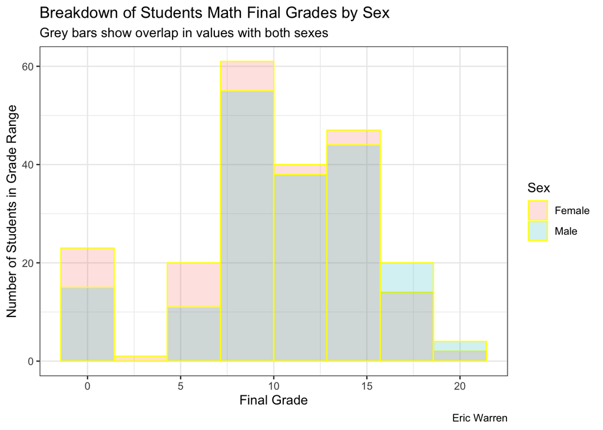

```r
ggplot(math_scores2) +
  geom_histogram(aes(x = G3, fill = sex),
                 col = "yellow",
                 bins = 8,
                 alpha = 0.2,
                 position = "identity") +
  labs(x = "Final Grade",
       y = "Number of Students in Grade Range",
       title = "Breakdown of Students Math Final Grades by Sex",
       fill = "Sex",
       caption = "Eric Warren",
       subtitle = "Grey bars show overlap in values with both sexes") +
  theme_bw()
```

Now we are going to make the density plot of `G1` scores with the grouping variable of `sex`.

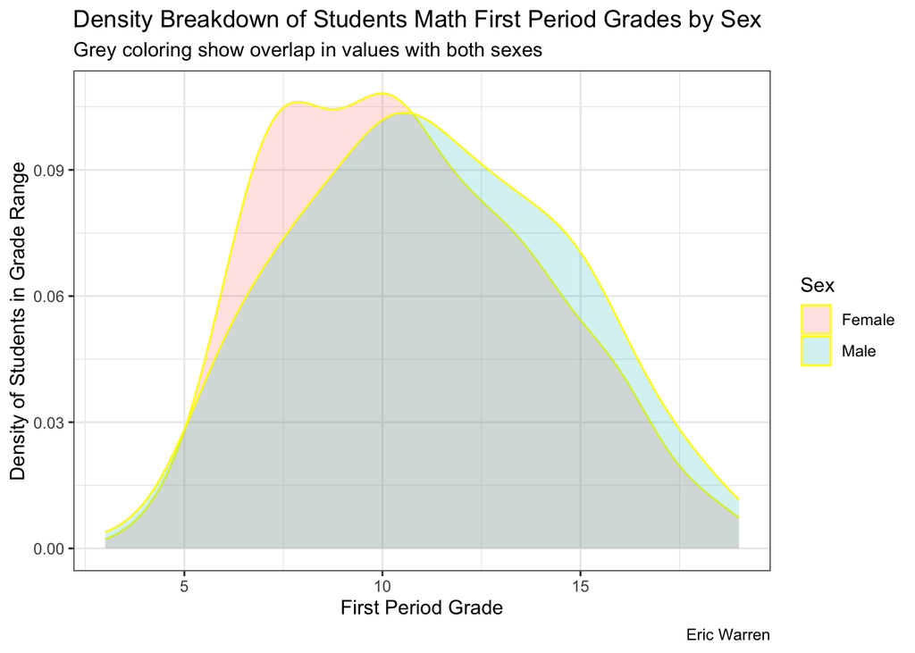

```r
ggplot(math_scores2) +
  geom_density(aes(x = G1, fill = sex),
                 col = "yellow",
                 alpha = 0.2,
                 position = "identity") +
  labs(x = "First Period Grade",
       y = "Density of Students in Grade Range",
       title = "Density Breakdown of Students Math First Period Grades by Sex",
       fill = "Sex",
       caption = "Eric Warren",
       subtitle = "Grey coloring show overlap in values with both sexes") +
  theme_bw()
```

Now we are going to make the boxplot of `G1` scores with the grouping variable of `sex`.

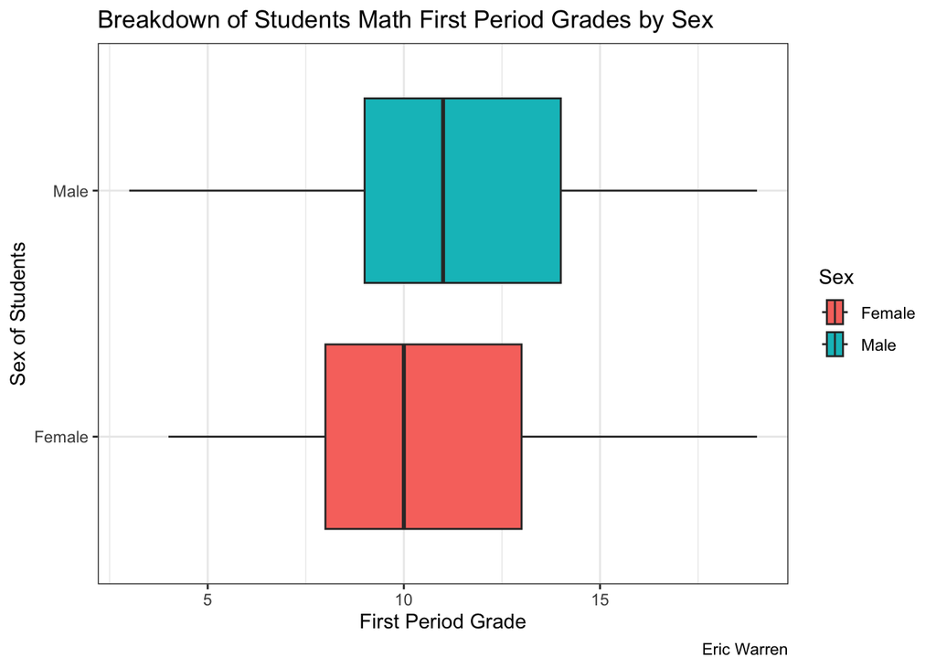

```r
ggplot(math_scores2) +
  geom_boxplot(aes(x = G1, y = sex, fill = sex)) +
  labs(x = "First Period Grade",
       y = "Sex of Students",
       title = "Breakdown of Students Math First Period Grades by Sex",
       fill = "Sex",
       caption = "Eric Warren") +
  theme_bw()
```

- Now we are going to create two scatterplots relating a `G3` variable to other numeric variables (put `G3` on the y-axis). You should jitter the points if they sit on top of each other. Color the points by a categorical variable in each. Add appropriate labels and titles.

We are going to continue looking at math scores. For our first scatterplot, we are going to look at `G1` compared to `G3` with `sex` being our grouping variable.

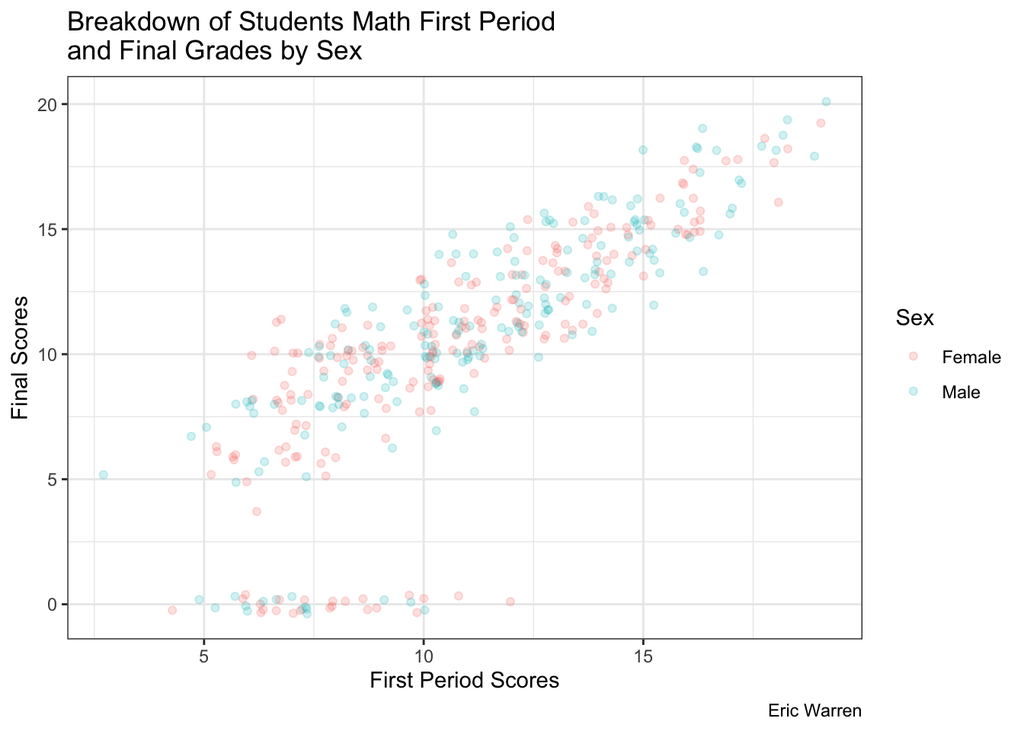

```r
ggplot(math_scores2) +
  geom_point(aes(x = G1, y = G3, col = sex),
             alpha = 0.2,
             position = "jitter") +
  labs(x = "First Period Scores",
       y = "Final Scores",
       title = "Breakdown of Students Math First Period \nand Final Grades by Sex",
       col = "Sex",
       caption = "Eric Warren") +
  theme_bw()
```

There are some things to note from this plot. First, it seems to be a linear increasing trend with `G3` scores onto `G1` scores. We can also see some more males in the upper right (which indicates good scores for both) and more females on the left and bottom (which indicates not so good scores for both). Is there a chance that `sex` also plays a factor onto both grade variables? If we made a model should we include `sex` as a predictor?

For our other scatterplot, we are going to look at `absences` compared to `G3` with `sex` being our grouping variable.

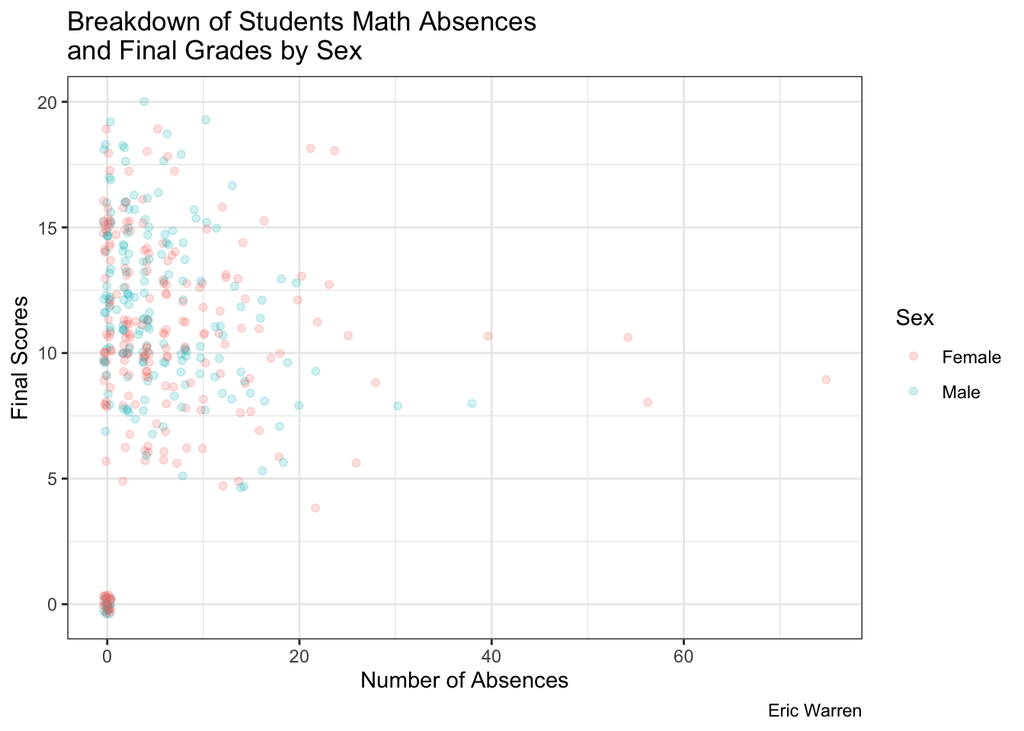

```r
ggplot(math_scores2) +
  geom_point(aes(x = absences, y = G3, col = sex),
             alpha = 0.2,
             position = "jitter") +
  labs(x = "Number of Absences",
       y = "Final Scores",
       title = "Breakdown of Students Math Absences \nand Final Grades by Sex",
       col = "Sex",
       caption = "Eric Warren") +
  theme_bw()
```

There are some things to note from this plot. First, we can see that most students do not have many `absences`. So if we tried to make a model it would be very hard to use `absences` as a predictor. Another thing interesting to note is that it seems that females tend to miss more (or more females are on the outlier part). Could this be the reason why female grades are worse than male grades for the final in math?

- Now we are going to repeat our scatterplots but using another grouping variable of `internet` to facet our plots.

We are going to continue looking at math scores. For our first scatterplot, we are going to look at `G1` compared to `G3` with `sex` being our grouping variable for the color of points and `internet` being our grouping variable causing us to facet the plots that way.

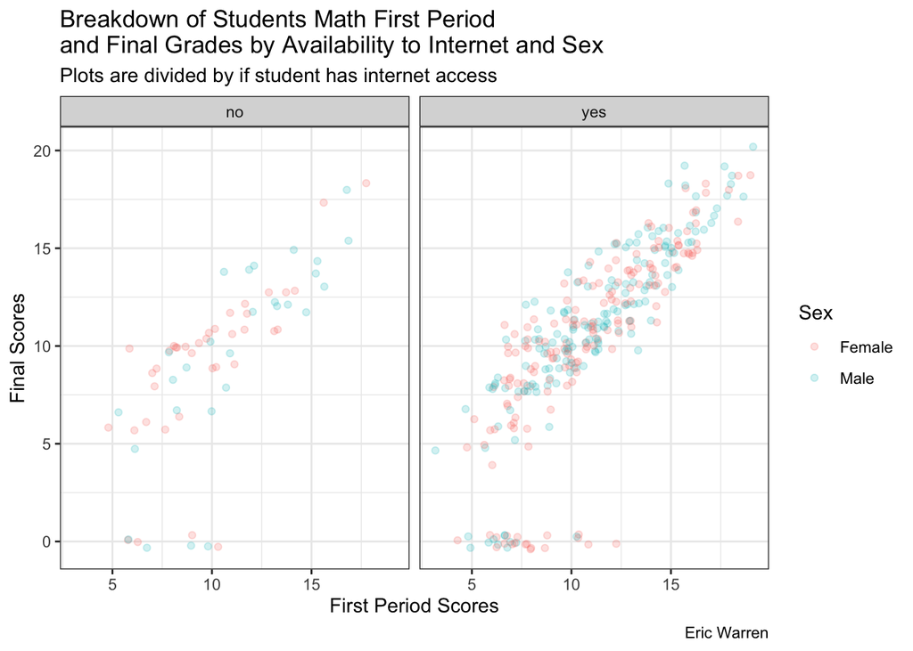

```r
ggplot(math_scores2) +
  geom_point(aes(x = G1, y = G3, col = sex),
             alpha = 0.2,
             position = "jitter") +
  labs(x = "First Period Scores",
       y = "Final Scores",
       title = "Breakdown of Students Math First Period \nand Final Grades by Availability to Internet and Sex",
       subtitle = "Plots are divided by if student has internet access",
       col = "Sex",
       caption = "Eric Warren") +
  facet_wrap(~ internet) +
  theme_bw()
```

Other than trends mentioned before, it does not look like internet access causes grades to shift in a negative way. In the US, we think this causes a distinct disadvantage if a student does not have internet access, but it seems like here it does not. It does seem more females do not have internet access and males and females scores don’t seem as different grouping them this way.

For our next scatterplot, we are going to look at `absences` compared to `G3` with `sex` being our grouping variable for the color of points and `internet` being our grouping variable causing us to facet the plots that way.

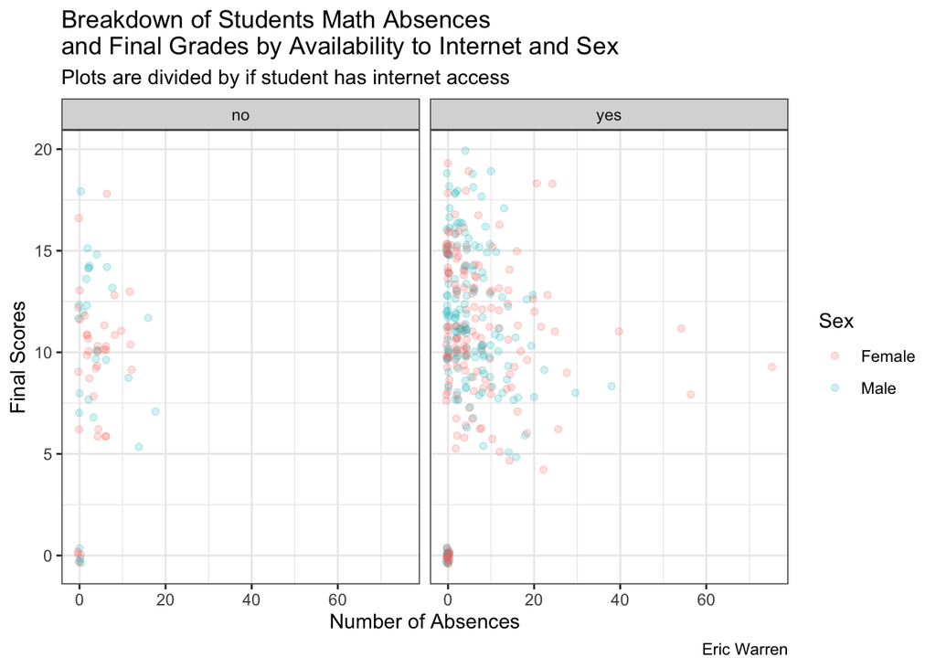

```r
ggplot(math_scores2) +
  geom_point(aes(x = absences, y = G3, col = sex),
             alpha = 0.2,
             position = "jitter") +
  labs(x = "Number of Absences",
       y = "Final Scores",
       title = "Breakdown of Students Math Absences \nand Final Grades by Availability to Internet and Sex",
       subtitle = "Plots are divided by if student has internet access",
       col = "Sex",
       caption = "Eric Warren") +
  facet_wrap(~ internet) +
  theme_bw()
```

Other than trends mentioned before, it seems that students without `internet` access tend to not have as many `absences`. Their scores seem pretty close to their counterparts who do have `internet`. There might be some students who have a smaller range of final scores on the upper end but again seems close. The big takeaway is that the number of `absences` seems lower.

- Now we are going to repeat our scatterplots but using the grouping variables of `internet` and `sex` to facet our plots. Rather than 2 plots with different colors, we should expect 4 plots total.

We are going to continue looking at math scores. For our first scatterplot, we are going to look at `G1` compared to `G3` with `internet` and `sex` being our grouping variables causing us to facet the plots that way.

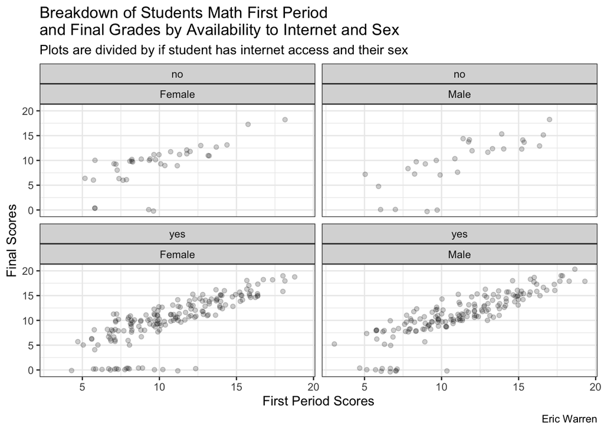

```r
ggplot(math_scores2) +
  geom_point(aes(x = G1, y = G3),
             alpha = 0.2,
             position = "jitter") +
  labs(x = "First Period Scores",
       y = "Final Scores",
       title = "Breakdown of Students Math First Period \nand Final Grades by Availability to Internet and Sex",
       subtitle = "Plots are divided by if student has internet access and their sex",
       caption = "Eric Warren") +
  facet_wrap(vars(internet, sex)) +
  theme_bw()
```

Other than what was said before, it seems to be that males with and without internet tend to score better than females on both grades (but especially the final grade). This difference seems a little more noticable of males versus females when looking at students without internet access.

We are going to continue looking at math scores. For our first scatterplot, we are going to look at `absences` compared to `G3` with `internet` and `sex` being our grouping variables causing us to facet the plots that way.

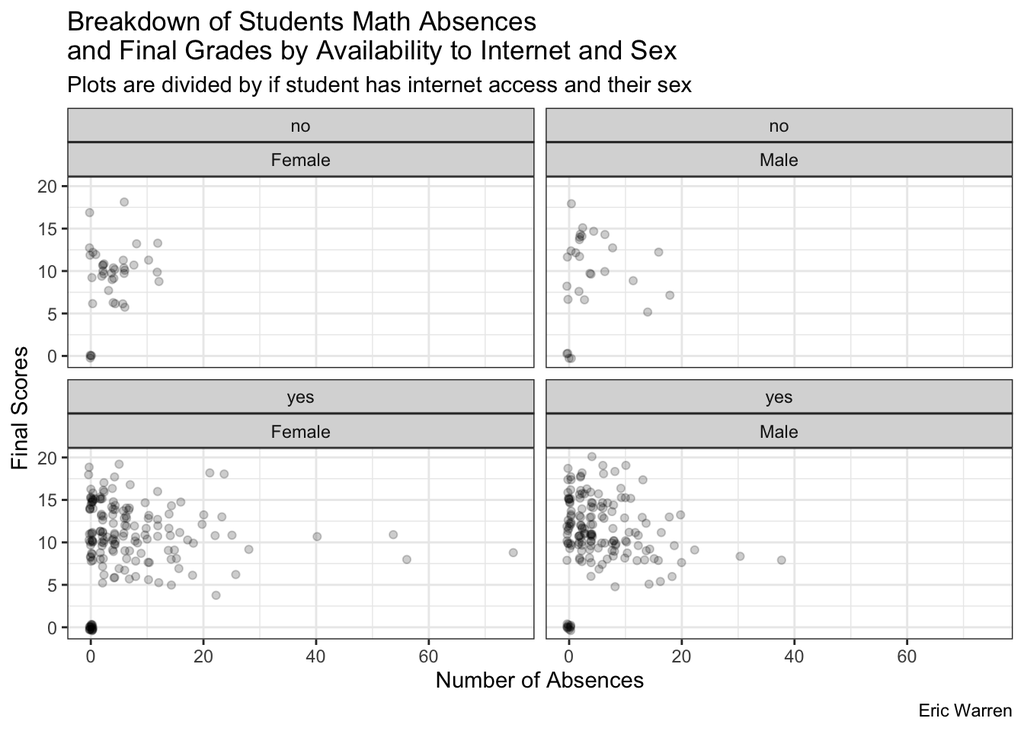

```r
ggplot(math_scores2) +
  geom_point(aes(x = absences, y = G3),
             alpha = 0.2,
             position = "jitter") +
  labs(x = "Number of Absences",
       y = "Final Scores",
       title = "Breakdown of Students Math Absences \nand Final Grades by Availability to Internet and Sex",
       subtitle = "Plots are divided by if student has internet access and their sex",
       caption = "Eric Warren") +
  facet_wrap(vars(internet, sex)) +
  theme_bw()
```

Other than what was said before, it seems that male students without internet tend to have more `absences` than female students without internet, but female students with internet tend to have more `absences` than male students with internet. It also seems from this plot that males have higher scores on the final (`G3`) value than females.